# Wrap-up

Marcel Neunhoeffer & Oliver Rittmann & Dennis Cohen

November 28, 2019 | December 2, 2019 | December 3, 2019

Today:

1. Throwback Thursday
2. Bugfixing: sapply and for loops
3. Visualizing Interactions in Logit Models or Count Models

Goals for Today:

- See what you learned this semester
- Bugfixing
- How to visualize Interactions in Logit Models

`r`r rm(list = ls())

# 1.Throwback Thursday

Remember your first two lab exercises?

## Exercise I:

- Create three objects:
  1. “my.lucky.number” it should contain your lucky number
  2. “my.firstname” it should contain your firstname
  3. “my.lastname” it should contain your lastname

After you created the objects, call them separately. Don’t forget to add comments to your code.

## Exercise II: Generate a vector with two sequences of your choice.

1. give your vector a meaningful name
2. calculate the mean value of your vector and save the result as exercise.mean
3. calculate the variance of your vector and save the result as exercise.var
4. don’t forget to add comments

Remember your first homework?

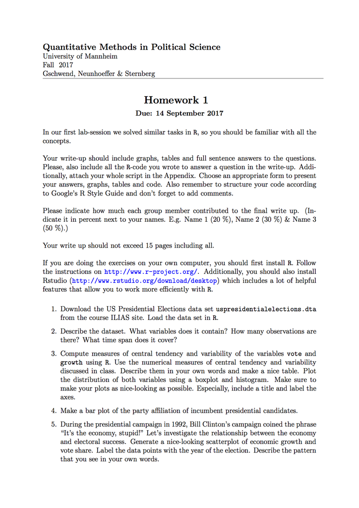

Homework 1.

It took quite some time back then…

How long do you think would it take you now?

So we think you are well prepared to master the Data Essay! It’s really amazing what you learnt this semester.

So let’s add two more things to the things you learnt…

# 2. Bugfixing: sapply and for loops

## The Bug

Bugs are a part of coding. Every now and then something goes wrong. And then for a while no one notices. If someone does discover your bug you feel horrible. And wonder how that could happen. Then you start debugging…

In the last lab we introduced the following code (no excuse, but that bit of code was part of the lab for at least 4 years…).

```r
exp.auto <- sapply(lambda1, function(x) mean(rnbinom(1000, size = theta, mu = lambda1[x])))
```

We said it would do the same thing as the following for loop.

```r
mean.auto <- rep(NA, length(lambda1))

for(i in 1:length(lambda1)){

mean.auto[i] <- mean(rnbinom(1000, size = theta, mu = lambda1[i]))

}
```

Spoiler… It doesn’t.

Let’s check that with an example.

See the wrong sapply in action.

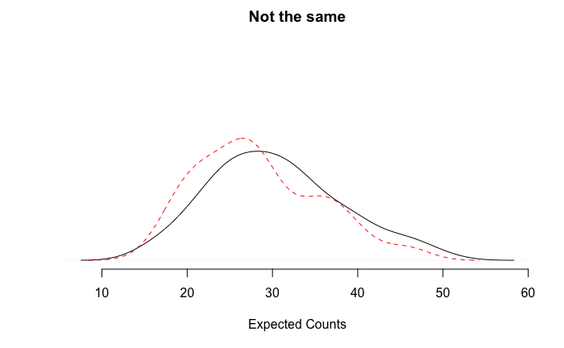

Unfortunately, we can all see now that the results are not the same.

## Trying to understand what it does

`r`r #?sapply

**So what went wrong?**

`r`r seq <- 4:10 res.for <- rep(NA, length(seq)) for(i in 1:length(seq)){ res.for[i] <- seq[i] + 2 } res.sapplyWrong <- sapply(seq, function(x) seq[x] + 2) res.sapplyRight <- sapply(seq, function(x) x + 2) cbind(res.for, res.sapplyWrong, res.sapplyRight)

```
     res.for res.sapplyWrong res.sapplyRight
[1,]       6               9               6
[2,]       7              10               7
[3,]       8              11               8
[4,]       9              12               9
[5,]      10              NA              10
[6,]      11              NA              11
[7,]      12              NA              12
```

## How to do it right?

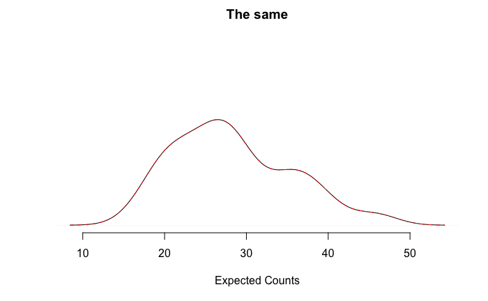

Now we have correct code for the last lab. And sapply and the for loop finally do the same thing!

(We included it already in the solution file for the last lab…)

# 3. Visualizing Interactions in Logit Models

Unfortunately, the intuition about interaction terms form linear models does not extend to non-linear models.

However, we have one really powerful tool in our toolbox that can help us to look at and interpret interactions in any model. Simulation!

As some of you had problems with the interaction effect in a logit model in Homework 9, we will look at an interaction in a logit model here.

The same logic applies to any other non-linear model.

For the last time, we will start with some fake data.

`r`r # Population Size n <- 100000 # True Parameters beta0 <- -2 beta1 <- 0.3 beta2 <- 0.5 beta3 <- -0.2 # Independent Variables X1 <- rnorm(n, 20, 10) X2 <- rnorm(n, 1, 0.5) # Our Systematic component mu <- beta0 + beta1*X1 + beta2*X2 + beta3*X1*X2 # Now we generate p via the logit response function p <- (exp(mu)) / (1 + exp(mu)) # As we observe only 0 or 1 we need to put p in a binomial distribution Y <- rbinom(n, 1, p) # That’s our full population. pop <- data.frame(Y, X1, X2) # Let’s work with a sample from our population data <- pop[sample(1:10000, 1000), ] # Now we can run the model… m1 <- glm(Y ~ X1 + X2 + X1*X2, data = data, family = binomial(link = logit)) summary(m1)

```
Call:
glm(formula = Y ~ X1 + X2 + X1 * X2, family = binomial(link = logit),
    data = data)

Deviance Residuals:
     Min        1Q    Median        3Q       Max
-2.77946  -0.77560   0.08492   0.73699   2.85333

Coefficients:
            Estimate Std. Error z value Pr(>|z|)
(Intercept) -2.47580    0.44922  -5.511 3.56e-08 ***
X1           0.32581    0.02947  11.054  < 2e-16 ***
X2           0.88222    0.37300   2.365    0.018 *
X1:X2       -0.22482    0.02379  -9.450  < 2e-16 ***
---
Signif. codes:  0 ‘***’ 0.001 ‘**’ 0.01 ‘*’ 0.05 ‘.’ 0.1 ‘ ’ 1

(Dispersion parameter for binomial family taken to be 1)

    Null deviance: 1383.99  on 999  degrees of freedom
Residual deviance:  930.02  on 996  degrees of freedom
AIC: 938.02

Number of Fisher Scoring iterations: 6
```

So now we can’t make sense of these coefficients…

# To see what those coefficients mean, we use simulation.

## A. Simulate Parameters - Remember the Steps?

Steps for Simulating Parameters:

- 1. Get the coefficients from the regression (gamma.hat)
- 2. Get the variance-covariance matrix (V.hat)
- 3. Set up a multivariate normal distribution N(gamma.hat,V.hat)
- 4. Draw from the distribution nsim times

`r`r gamma.hat <- coef(m1) V.hat <- vcov(m1) library(MASS) S <- mvrnorm(1000, gamma.hat, V.hat)

## B. Calculate Expected Values

Set up interesting scenarios. That’s the important step here!

`r`r X1.sim <- seq(min(X1), max(X1), length.out = 100) X2.lo <- quantile(X2, 0.25) X2.hi <- quantile(X2, 0.75) scenario.X2lo <- cbind(1, X1.sim, X2.lo, X1.sim*X2.lo) scenario.X2hi <- cbind(1, X1.sim, X2.hi, X1.sim*X2.hi) Xbeta.lo <- S %*% t(scenario.X2lo) Xbeta.hi <- S %*% t(scenario.X2hi) dim(Xbeta.lo)

```
[1] 1000  100
```

`r`r dim(Xbeta.hi)

```
[1] 1000  100
```

`r`r # To get expected values for p, we need to plug in the Xbeta values into # the response function to get simulatd probabilities p.sim.lo <- (exp(Xbeta.lo))/ (1 + exp(Xbeta.lo)) p.sim.hi <- (exp(Xbeta.hi))/ (1 + exp(Xbeta.hi)) dim(p.sim.lo)

```
[1] 1000  100
```

`r`r dim(p.sim.hi)

```
[1] 1000  100
```

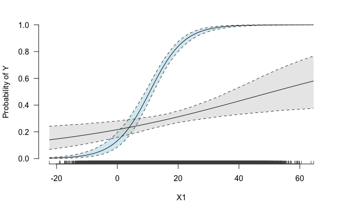

How about looking at the first difference of the two scenarios directly?

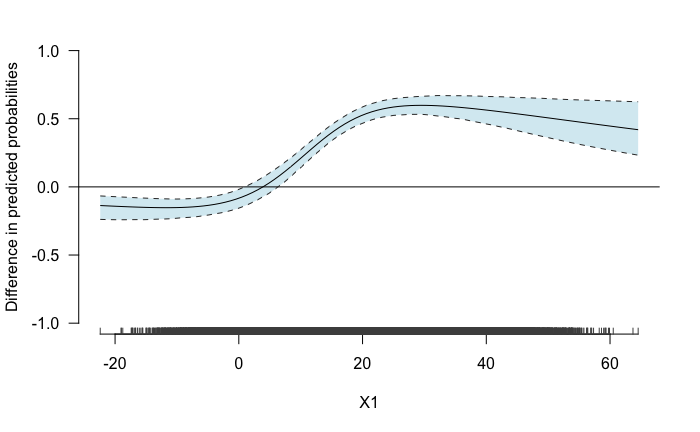

That looks funky (and not linear at all…).

# Concluding Remarks

Great job everyone! You can be really proud of what you achieved.

Good luck with the Data Essay. We are confident that you have all the tools you need to master it!